# R4DS - Data Vis

You can even extend what was set by default by further specifying things inside of the geoms.

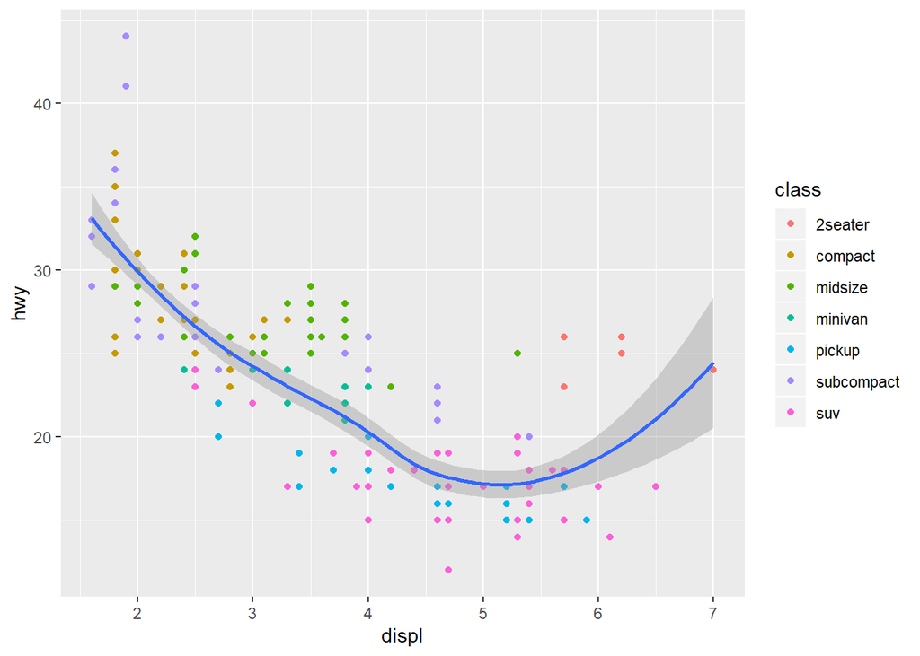

```r
ggplot(data = mpg, mapping = aes(x = displ, y = hwy)) +
  geom_point(aes(color=class)) +
  geom_smooth()
```

You can even specify which points to filter for.

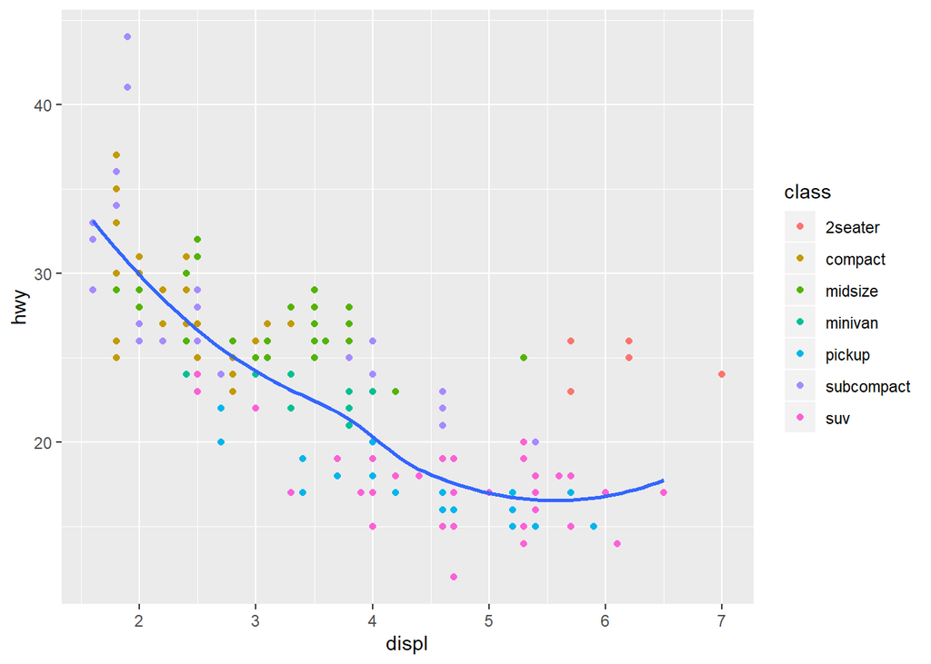

```r
ggplot(data = mpg, mapping = aes(x = displ, y = hwy)) +
  geom_point(aes(color=class)) +
  geom_smooth(data=filter(mpg, class!="2seater"), se=FALSE)
```

Here, our smooth geom is ignoring the 2 seaters which were annoying from before, I think I might also ignore displ that are higher than 6.

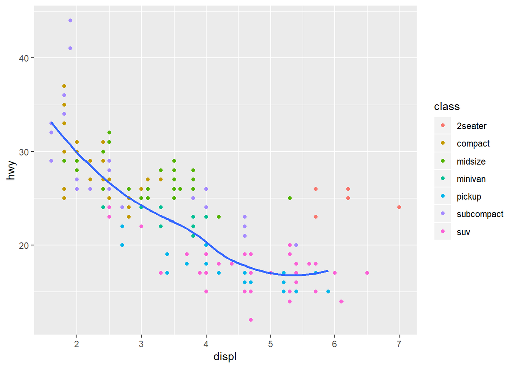

```r
ggplot(data = mpg, mapping = aes(x = displ, y = hwy)) +
  geom_point(aes(color=class)) +
  geom_smooth(data=filter(mpg, class!="2seater", displ<6), se=FALSE)
```

Note that the `se` parameter dictates whether loess smoothing comes with a confidence interval.

We can also change it so that it does a linear regression.

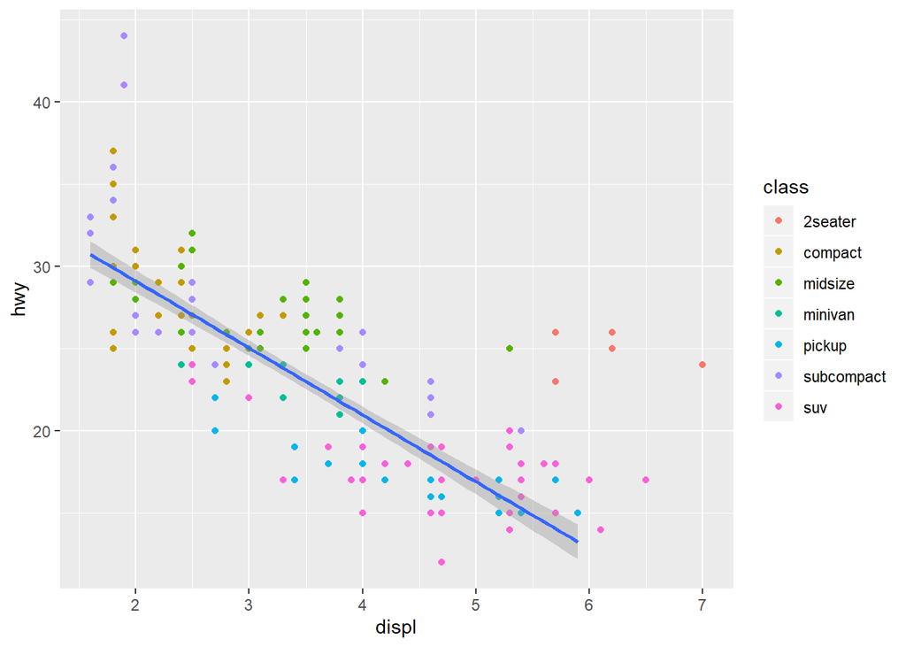

```r
ggplot(data = mpg, mapping = aes(x = displ, y = hwy)) +
  geom_point(aes(color=class)) +
  geom_smooth(data=filter(mpg, class!="2seater", displ<6), method='lm')
```